# Chapter 07

Scott Spencer

8/27/2018

The code below is meant as a directly-in-Stan translation of the examples in Chapter 7 of McElreath’s *Statistical Rethinking*.

## 7.1 Building an interaction

Load data.

```r
data('rugged', package = 'rethinking')
d  <- rugged; rm(rugged)
```

Transform data.

```r
d$loggdp <- log(d$rgdppc_2000)
d <- d[complete.cases(d$loggdp),]
d.A1 <- d[d$cont_africa==1,]
d.A0 <- d[d$cont_africa==0,]
```

Code model.

```stan
data {
  int N;
  vector[N] loggdp;
  vector[N] rugged;
}
parameters {
  real a;
  real bR;
  real<lower=0, upper=10> sigma;
}
model {
  vector[N] mu = a + bR * rugged;
  target += normal_lpdf(loggdp | mu, sigma);
  target += normal_lpdf(a | 8, 100);
  target += normal_lpdf(bR | 0, 1);
}
```

Organize data and sample from model.

```r
m07_2 <- m07_1

dat <- list(
  N = NROW(d.A1),
  loggdp = d.A1$loggdp,
  rugged = d.A1$rugged
)

fit07_1 <- sampling(m07_1, data = dat, iter = 10000, chains = 4, cores = 4)
```

```r
post <- as.data.frame(fit07_1)

mu <- post$a + d.A1$rugged %*% t(post$bR)
mu_mean <- rowMeans(mu)
mu_hpdi <- apply(mu, 1, rethinking::HPDI)

# simulate loggdp
iter <- 1e5
y_hat <- matrix(nrow = iter, ncol = NROW(d.A1))
for(i in 1:NROW(d.A1)) y_hat[,i] <- rnorm(iter, post[,"a"] + d.A1[i,"rugged"] %*% t(post[,"bR"]), post[,"sigma"])

# get stats on sim
y_hat_avg <- colMeans(y_hat)
y_hat_pi <- apply(y_hat, 2, rethinking::PI)
```

Figure 7.2a

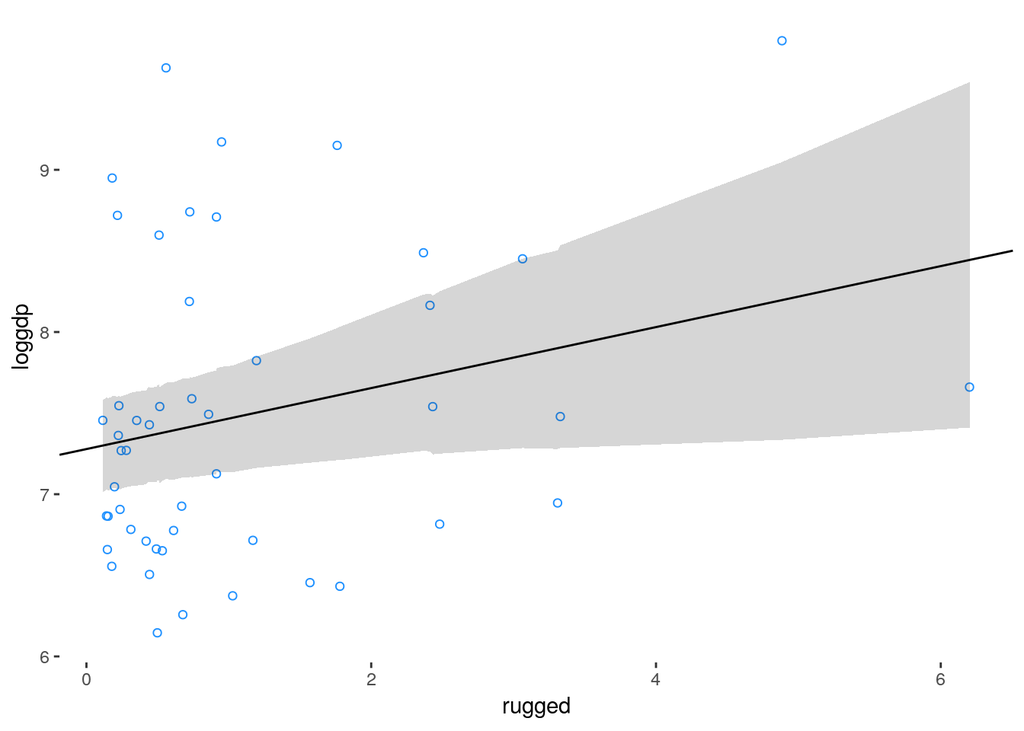

```r
ggplot() +
  geom_point(data = d.A1,
             aes(rugged, loggdp), shape = 21, color = 'dodgerblue') +
  #geom_ribbon(aes(x = d.A1$rugged, ymin = y_hat_pi[1,], ymax = y_hat_pi[2,]), alpha = .2) +
  geom_ribbon(aes(x = d.A1$rugged, ymin = mu_hpdi[1,], ymax = mu_hpdi[2,]), alpha = .2) +
  geom_abline(slope = mean(post$bR), intercept = mean(post$a) )
```

```r
dat <- list(
  N = NROW(d.A0),
  loggdp = d.A0$loggdp,
  rugged = d.A0$rugged
)

fit07_2 <- sampling(m07_2, data = dat, iter = 10000, chains = 4, cores = 4)
```

```r
post <- as.data.frame(fit07_2)

mu <- post$a + d.A0$rugged %*% t(post$bR)
mu_mean <- rowMeans(mu)
mu_hpdi <- apply(mu, 1, rethinking::HPDI)

# simulate loggdp
iter <- 1e5
y_hat <- matrix(nrow = iter, ncol = NROW(d.A0))
for(i in 1:NROW(d.A0)) y_hat[,i] <- rnorm(iter, post[,"a"] + d.A0[i,"rugged"] %*% t(post[,"bR"]), post[,"sigma"])

# get stats on sim
y_hat_avg <- colMeans(y_hat)
y_hat_pi <- apply(y_hat, 2, rethinking::PI)
```

Figure 7.2b

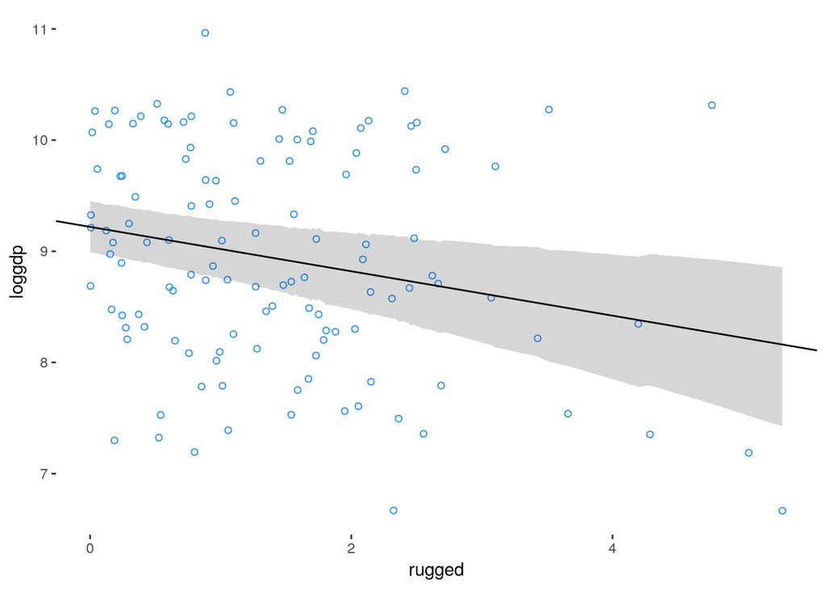

```r
ggplot() +
  geom_point(data = d.A0,
             aes(rugged, loggdp), shape = 21, color = 'dodgerblue') +
  #geom_ribbon(aes(x = d.A0$rugged, ymin = y_hat_pi[1,], ymax = y_hat_pi[2,]), alpha = .2) +
  geom_ribbon(aes(x = d.A0$rugged, ymin = mu_hpdi[1,], ymax = mu_hpdi[2,]), alpha = .2) +
  geom_abline(slope = mean(post$bR), intercept = mean(post$a) )
```

### 7.1.1 Adding a dummy variable doesn’t work

First re-sample model above with all data (with and without Africa). Need to re-code model to include log likelihood in `generated quantities` block since we will be comparing the two models.

```stan
data {
  int N;
  vector[N] loggdp;
  vector[N] rugged;
}
parameters {
  real a;
  real bR;
  real<lower=0, upper=10> sigma;
}
model {
  vector[N] mu = a + bR * rugged;
  target += normal_lpdf(loggdp | mu, sigma);
  target += normal_lpdf(a | 8, 100);
  target += normal_lpdf(bR | 0, 1);
}
generated quantities {
  vector[N] log_lik;
  {
  vector[N] mu;
  for(n in 1:N) {
    mu[n] = a + bR * rugged[n];
    log_lik[n] = normal_lpdf(loggdp[n] | mu[n], sigma);
  }
  }
}
```

```r
dat <- list(
  N = NROW(d),
  loggdp = d$loggdp,
  rugged = d$rugged
)

fit07_3 <- sampling(m07_3, data = dat, iter = 10000, chains = 4, cores = 4)
```

Now code a model that uses a dummary variable for Africa.

```stan
data {
  int N;
  vector[N] loggdp;
  vector[N] rugged;
  vector<lower=0,upper=1>[N] cont_africa;
}
parameters {
  real a;
  real bR;
  real bA;
  real<lower=0, upper=10> sigma;
}
model {
  vector[N] mu = a + bR * rugged + bA * cont_africa;
  target += normal_lpdf(loggdp | mu, sigma);
  target += normal_lpdf(a | 8, 100);
  target += normal_lpdf(bR | 0, 1);
  target += normal_lpdf(bA | 0, 1);
}
generated quantities {
  vector[N] log_lik;
  {
  vector[N] mu;
  for(n in 1:N) {
    mu[n] = a + bR * rugged[n] + bA * cont_africa[n];
    log_lik[n] = normal_lpdf(loggdp[n] | mu[n], sigma);
  }
  }
}
```

```r
dat <- list(
  N = NROW(d),
  loggdp = d$loggdp,
  rugged = d$rugged,
  cont_africa = d$cont_africa
)

fit07_4 <- sampling(m07_4, data = dat, iter = 10000, chains = 4, cores = 4)
```

Calculate WAIC and compare models

```r
# compare models
library(loo)

log_lik_07_3 <- extract_log_lik(fit07_3, merge_chains = FALSE)
waic07_3 <- waic(log_lik_07_3)

log_lik_07_4 <- extract_log_lik(fit07_4, merge_chains = FALSE)
waic07_4 <- waic(log_lik_07_4)

mod_comp <- compare(waic07_3, waic07_4)
mod_comp
```

```
## elpd_diff        se
##      31.7       7.3
```

TODO: above does not include model weighting.

Plot predictions using model `m07_4`.

```r
post <- as.data.frame(fit07_4)

mu <- post$a + d$rugged %*% t(post$bR) + d$cont_africa %*% t(post$bA)
mu_mean <- rowMeans(mu)
mu_hpdi <- apply(mu, 1, rethinking::HPDI)

# simulate loggdp
iter <- 1e5
y_hat <- matrix(nrow = iter, ncol = NROW(d))
for(i in 1:NROW(d)) y_hat[,i] <- rnorm(iter, post[,"a"] + d[i,"rugged"] %*% t(post[,"bR"]) + d[i,"cont_africa"] %*% t(post[,"bA"]), post[,"sigma"])

# get stats on sim
y_hat_avg <- colMeans(y_hat)
y_hat_pi <- apply(y_hat, 2, rethinking::PI)
```

Figure 7.3

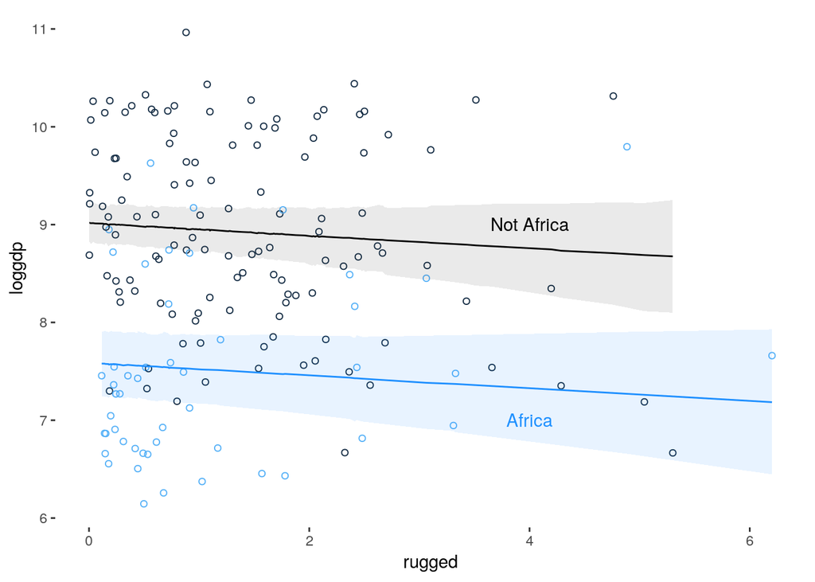

```r
d_04 <- d %>%
  mutate(mu_mean = mu_mean,
         mu_hpdi_l = mu_hpdi[1,],
         mu_hpdi_h = mu_hpdi[2,])

ggplot(d_04) +
  geom_point(aes(rugged, loggdp, color = cont_africa), shape = 21) +
  theme(legend.position = '') +
  geom_line(data = d_04 %>% filter(cont_africa == 0),
            aes(rugged, mu_mean)) +
  geom_ribbon(data = d_04 %>% filter(cont_africa == 0),
              aes(x=rugged, ymin=mu_hpdi_l, ymax=mu_hpdi_h), alpha = .1) +
  geom_line(data = d_04 %>% filter(cont_africa == 1),
            aes(rugged, mu_mean), color = 'dodgerblue') +
  geom_ribbon(data = d_04 %>% filter(cont_africa == 1),
              aes(x=rugged, ymin=mu_hpdi_l, ymax=mu_hpdi_h), alpha = .1, fill = 'dodgerblue') +
  annotate('text', x = 4, y = 9, label = "Not Africa") +
  annotate('text', x = 4, y = 7, label = "Africa", color = 'dodgerblue')
```

### 7.1.2 Adding a linear interaction does work

Code the model.

```stan
data {
  int N;
  vector[N] loggdp;
  vector[N] rugged;
  vector<lower=0,upper=1>[N] cont_africa;
}
parameters {
  real a;
  real bR;
  real bA;
  real bAR;
  real<lower=0, upper=10> sigma;
}
model {
  vector[N] gamma;
  vector[N] mu;

  for (i in 1:N) {
    gamma[i] = bR + bAR * cont_africa[i];
    mu[i] = a + gamma[i] * rugged[i] + bA * cont_africa[i];
  }

  target += normal_lpdf(loggdp | mu, sigma);
  target += normal_lpdf(a | 8, 100);
  target += normal_lpdf(bR | 0, 1);
  target += normal_lpdf(bA | 0, 1);
  target += normal_lpdf(bAR | 0, 1);
}
generated quantities {
  vector[N] log_lik;
  {
  vector[N] mu; vector[N] gamma;
  for(n in 1:N) {
    gamma[n] = bR + bAR * cont_africa[n];
    mu[n] = a + gamma[n] * rugged[n] + bA * cont_africa[n];
    log_lik[n] = normal_lpdf(loggdp[n] | mu[n], sigma);
  }
  }
}
```

```r
dat <- list(
  N = NROW(d),
  loggdp = d$loggdp,
  rugged = d$rugged,
  cont_africa = d$cont_africa
)

fit07_5 <- sampling(m07_5, data = dat, iter = 10000, chains = 4, cores = 4)
```

Compare three models.

```r
log_lik_07_5 <- extract_log_lik(fit07_5, merge_chains = FALSE)
waic07_5 <- waic(log_lik_07_5)

mod_comp <- compare(waic07_3, waic07_4, waic07_5)
mod_comp
```

```
##          elpd_diff elpd_waic se_elpd_waic p_waic se_p_waic waic   se_waic
## waic07_5    0.0    -234.6       7.3          5.0    0.9     469.3   14.5
## waic07_4   -3.4    -238.0       7.4          4.1    0.8     476.1   14.8
## waic07_3  -35.1    -269.7       6.5          2.6    0.3     539.4   13.0
```

Overthinking

```stan
data {
  int N;
  vector[N] loggdp;
  vector[N] rugged;
  vector<lower=0,upper=1>[N] cont_africa;
}
parameters {
  real a;
  real bR;
  real bA;
  real bAR;
  real<lower=0, upper=10> sigma;
}
model {
  vector[N] mu;

  for (i in 1:N) {
    mu[i] = a + bR * rugged[i] + bAR * rugged[i] * cont_africa[i] + bA * cont_africa[i];
  }

  target += normal_lpdf(loggdp | mu, sigma);
  target += normal_lpdf(a | 8, 100);
  target += normal_lpdf(bR | 0, 1);
  target += normal_lpdf(bA | 0, 1);
  target += normal_lpdf(bAR | 0, 1);
}
generated quantities {
  vector[N] log_lik;
  {
  vector[N] mu; vector[N] gamma;
  for(n in 1:N) {
    gamma[n] = bR + bAR * cont_africa[n];
    mu[n] = a + gamma[n] * rugged[n] + bA * cont_africa[n];
    log_lik[n] = normal_lpdf(loggdp[n] | mu[n], sigma);
  }
  }
}
```

### 7.1.3 Plotting the interaction

```r
post07_5 <- as.data.frame(fit07_5)

f_mu_07_5 <- function(rugged, cont_africa) with(post07_5,
             a + bR * rugged + bAR * rugged * cont_africa + bA * cont_africa )

mu_07_5 <- mapply(f_mu_07_5, rugged = d$rugged, cont_africa = d$cont_africa)

mu_07_5_mean <- apply(mu_07_5, 2, mean)
mu_07_5_pi <- apply(mu_07_5, 2, rethinking::PI, prob = .97)

d_07_5 <- d %>%
  mutate(mu_mean = mu_07_5_mean,
         mu_pi_l = mu_07_5_pi[1,],
         mu_pi_h = mu_07_5_pi[2,],
         inAfrica = ifelse(cont_africa, 'African nations', 'Non-African nations'))
```

Figure 7.4

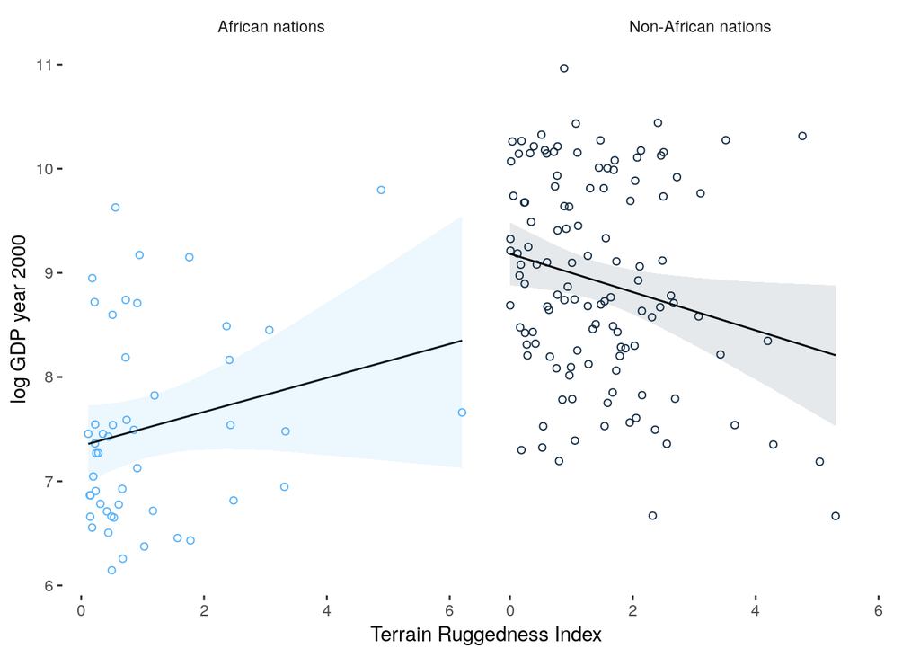

```r
ggplot(d_07_5) +
  geom_point(aes(rugged, loggdp, color = cont_africa), shape = 21) +
  theme(legend.position = '') +
  geom_line(aes(rugged, mu_mean)) +
  geom_ribbon(aes(x=rugged, ymin=mu_pi_l, ymax=mu_pi_h, fill = cont_africa), alpha = .1) +
  facet_wrap(~inAfrica) +
  labs(x = 'Terrain Ruggedness Index', y = 'log GDP year 2000')
```

#### 7.1.4.1 parameters change meaning

Model summary

```r
print(fit07_5, probs = c(0.1, 0.5, 0.9), pars = c('a', 'bA', 'bR', 'bAR', 'sigma'))
```

```
## Inference for Stan model: c75d598a0924c725090498988bf55fee.
## 4 chains, each with iter=10000; warmup=5000; thin=1;
## post-warmup draws per chain=5000, total post-warmup draws=20000.
##
##        mean se_mean   sd   10%   50%   90% n_eff Rhat
## a      9.18       0 0.14  9.01  9.18  9.36  8664    1
## bA    -1.84       0 0.22 -2.13 -1.85 -1.56  8953    1
## bR    -0.18       0 0.08 -0.28 -0.18 -0.09  8444    1
## bAR    0.35       0 0.13  0.18  0.35  0.51  9245    1
## sigma  0.95       0 0.05  0.89  0.95  1.02 13280    1
##
## Samples were drawn using NUTS(diag_e) at Thu Jan 17 12:16:39 2019.
## For each parameter, n_eff is a crude measure of effective sample size,
## and Rhat is the potential scale reduction factor on split chains (at
## convergence, Rhat=1).
```

#### 7.1.4.2 Incorporating uncertainty

Calculate posterior for gamma

```r
post <- as.data.frame(fit07_5, pars = c('a', 'bA', 'bR', 'bAR'))
gamma_africa <- post$bR + post$bAR * 1
gamma_notafrica <- post$bR + post$bAR * 0
```

means

```r
c(mean(gamma_africa), mean(gamma_notafrica))
```

```
## [1]  0.1630077 -0.1837408
```

Figure 7.5

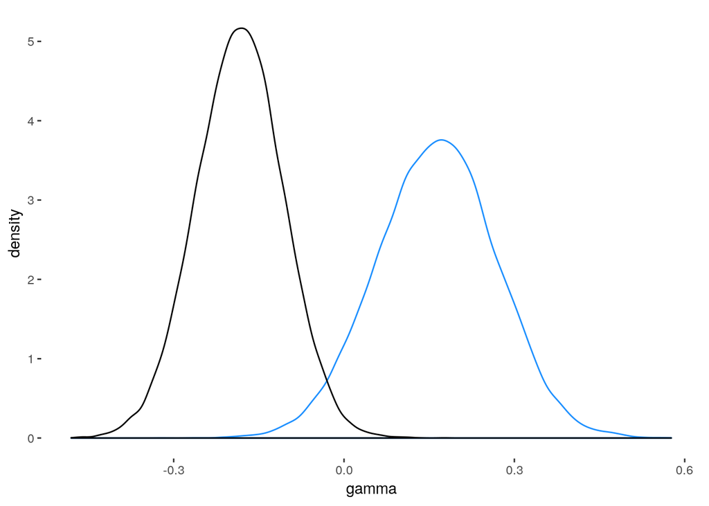

```r
ggplot() +
  geom_density(aes(gamma_africa), color = 'dodgerblue') +
  geom_density(aes(gamma_notafrica), color = 'black') +
  labs(x = 'gamma')
```

Difference between them

```r
diff <- gamma_africa - gamma_notafrica
sum( diff < 0 ) / length( diff )
```

```
## [1] 0.0053
```

## 7.2 Symmetric of the liner interaction

### 7.2.2 Africa depends on ruggedness

```r
d_07_5 <- d_07_5 %>%
  mutate(rugged_hi = rugged > median(rugged),
         inAfrica_num = as.integer(inAfrica=='African nations')) %>%
  mutate(inAfrica_num = ifelse(rugged_hi, inAfrica_num + .02, inAfrica_num))

d_imaginary <- d_07_5 %>% select(rugged) %>% range

# imaginary low values
mu_rugged_lo <- mapply(f_mu_07_5, rugged = d_imaginary[1], cont_africa = 0:1)
mu_rugged_lo_mean <- apply(mu_rugged_lo, 2, mean)
mu_rugged_lo_pi <- apply(mu_rugged_lo, 2, rethinking::PI, prob = .97)

# imaginary high values
mu_rugged_hi <- mapply(f_mu_07_5, rugged = d_imaginary[2], cont_africa = 0:1)
mu_rugged_hi_mean <- apply(mu_rugged_hi, 2, mean)
mu_rugged_hi_pi <- apply(mu_rugged_hi, 2, rethinking::PI, prob = .97)

# organize data
d_imag <-
  data.frame(inAfrica_num = 0:1,
             country = rep(c('lo', 'hi'), each = 2),
             loggdp_mean = c(mu_rugged_lo_mean, mu_rugged_hi_mean),
             loggdp_pi_l = c(mu_rugged_lo_pi[1,], mu_rugged_hi_pi[1,]),
             loggdp_pi_h = c(mu_rugged_lo_pi[2,], mu_rugged_hi_pi[2,]))
```

Figure 7.6

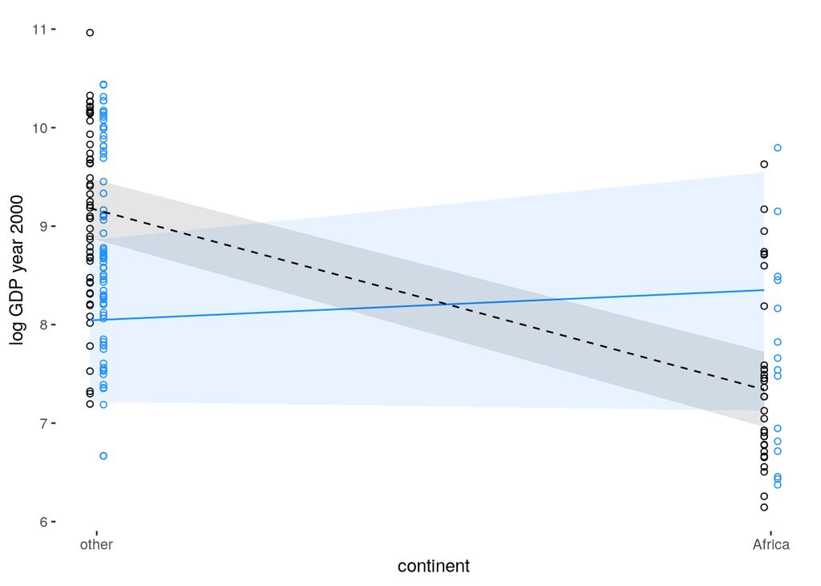

```r
ggplot() +
  # graph raw actual values
  geom_point(data = d_07_5,
             aes(inAfrica_num, loggdp, color = rugged_hi), shape = 21) +

  # graph imaginary hi values
  geom_ribbon(data = d_imag %>% filter(country == 'hi'),
              aes(x = inAfrica_num, y = loggdp_mean, ymin = loggdp_pi_l, ymax = loggdp_pi_h),
              alpha = .1, fill = 'dodgerblue') +
  geom_line(data = d_imag %>% filter(country == 'hi'),
              aes(x = inAfrica_num, y = loggdp_mean),
              color = 'dodgerblue') +

  # graph imaginary lo values
  geom_ribbon(data = d_imag %>% filter(country == 'lo'),
              aes(x = inAfrica_num, y = loggdp_mean, ymin = loggdp_pi_l, ymax = loggdp_pi_h),
              alpha = .1, fill = 'black') +
  geom_line(data = d_imag %>% filter(country == 'lo'),
              aes(x = inAfrica_num, y = loggdp_mean),
              color = 'black', linetype = 'dashed') +

  # other stuff
  scale_color_manual(values = c('black', 'dodgerblue')) +
  theme(legend.position = '') +
  labs(x = 'continent', y = 'log GDP year 2000') +
  scale_x_continuous(breaks = c(0.01, 1.01), labels = c('other', 'Africa'))
```

## 7.3 Continuous interactions

### 7.3.1 The data

Load the data

```r
data('tulips', package = 'rethinking')
d  <- tulips; rm(tulips)
```

### 7.3.2 The uncentered model

Code the two models

```stan
data {
  int N;
  vector[N] water;
  vector[N] shade;
  vector[N] blooms;
}
parameters {
  real a;
  real bW;
  real bS;
  real<lower=0> sigma;
}
model {
  vector[N] mu;
  target += normal_lpdf(a | 0, 100);
  target += normal_lpdf(bS | 0, 100);
  target += normal_lpdf(bW | 0, 100);
  target += uniform_lpdf(sigma | 0, 100);

  mu = a + bW * water + bS * shade;
  target += normal_lpdf(blooms | mu, sigma);

}
generated quantities {
  vector[N] log_lik;
  {
  vector[N] mu;
  for(i in 1:N) {
    mu[i] = a + bW * water[i] + bS * shade[i];
    log_lik[i] = normal_lpdf(blooms[i] | mu[i], sigma);
  }
  }
}
```

```stan
data {
  int N;
  vector[N] water;
  vector[N] shade;
  vector[N] blooms;
}
parameters {
  real a;
  real bW;
  real bS;
  real bWS;
  real<lower=0> sigma;
}
model {
  vector[N] mu;
  target += normal_lpdf(a | 0, 100);
  target += normal_lpdf(bS | 0, 100);
  target += normal_lpdf(bW | 0, 100);
  target += normal_lpdf(bWS | 0, 100);
  target += uniform_lpdf(sigma | 0, 100);

  mu = a + bW * water + bS * shade + bWS * water .* shade;
  target += normal_lpdf(blooms | mu, sigma);

}
generated quantities {
  vector[N] log_lik;
  {
  vector[N] mu;
  for(i in 1:N) {
    mu[i] = a + bW * water[i] + bS * shade[i] + bWS * water[i] * shade[i];
    log_lik[i] = normal_lpdf(blooms[i] | mu[i], sigma);
  }
  }
}
```

Organize data, fit, and sample from both models.

```r
dat <- list(N = NROW(d), water = d$water, shade = d$shade, blooms = d$blooms)
fit07_6 <- sampling(m07_6, data = dat, iter = 1000, chains = 2, cores = 2)
fit07_7 <- sampling(m07_7, data = dat, iter = 1000, chains = 2, cores = 2)
```

Summary of models

```r
print(fit07_6, include = F, pars = 'log_lik', probs = c(0.1, 0.5, 0.9))
```

```
## Inference for Stan model: 56b12321d0377a07a70c511ee78aa313.
## 2 chains, each with iter=1000; warmup=500; thin=1;
## post-warmup draws per chain=500, total post-warmup draws=1000.
##
##          mean se_mean    sd     10%     50%     90% n_eff Rhat
## a       44.74    8.69 43.03   -0.31   39.43  104.63    25 1.04
## bW      57.60   11.42 31.15    8.61   68.62   89.59     7 1.47
## bS     -26.25    8.91 27.20  -57.06  -33.81   15.40     9 1.26
## sigma   73.04    5.38 16.51   53.89   68.22   98.02     9 1.27
## lp__  -172.74    3.32  9.15 -190.30 -167.90 -166.03     8 1.35
##
## Samples were drawn using NUTS(diag_e) at Thu Jan 17 12:18:45 2019.
## For each parameter, n_eff is a crude measure of effective sample size,
## and Rhat is the potential scale reduction factor on split chains (at
## convergence, Rhat=1).
```

```r
print(fit07_7, include = F, pars = 'log_lik', probs = c(0.1, 0.5, 0.9))
```

```
## Inference for Stan model: 3a25c35206a02cdaf97728ad40a91ac4.
## 2 chains, each with iter=1000; warmup=500; thin=1;
## post-warmup draws per chain=500, total post-warmup draws=1000.
##
##          mean se_mean    sd     10%     50%     90% n_eff Rhat
## a      -79.83    3.67 50.60 -147.72  -80.04  -18.55   190 1.00
## bW     147.54    1.74 24.79  115.24  147.82  179.43   203 1.00
## bS      33.47    1.73 23.79    3.31   34.33   64.95   188 1.01
## bWS    -38.27    0.80 11.64  -53.24  -37.97  -23.17   214 1.01
## sigma   52.79    0.41  8.74   42.86   51.51   63.84   447 1.00
## lp__  -168.98    0.09  1.70 -171.22 -168.62 -167.17   341 1.00
##
## Samples were drawn using NUTS(diag_e) at Thu Jan 17 12:18:46 2019.
## For each parameter, n_eff is a crude measure of effective sample size,
## and Rhat is the potential scale reduction factor on split chains (at
## convergence, Rhat=1).
```

Compare models

```r
log_lik_07_6 <- extract_log_lik(fit07_6, merge_chains = FALSE)
waic07_6 <- waic(log_lik_07_6)

log_lik_07_7 <- extract_log_lik(fit07_7, merge_chains = FALSE)
waic07_7 <- waic(log_lik_07_7)

mod_comp <- compare(waic07_6, waic07_7)
mod_comp
```

```
## elpd_diff        se
##      17.7       5.1
```

For centering, we can use the same models, and just center the data given to them.

```r
dat <- list(N = NROW(d), water = d$water - mean(d$water), shade = d$shade - mean(d$shade), blooms = d$blooms)
fit07_8 <- sampling(m07_6, data = dat, iter = 10000, chains = 2, cores = 2)
fit07_9 <- sampling(m07_7, data = dat, iter = 10000, chains = 2, cores = 2)
```

Now summarise the centered versions.

```r
print(fit07_8, include = F, pars = 'log_lik', probs = c(0.1, 0.5, 0.9))
```

```
## Inference for Stan model: 56b12321d0377a07a70c511ee78aa313.
## 2 chains, each with iter=10000; warmup=5000; thin=1;
## post-warmup draws per chain=5000, total post-warmup draws=10000.
##
##          mean se_mean    sd     10%     50%     90% n_eff Rhat
## a      127.04    0.13 12.53  110.99  127.13  142.67  9908    1
## bW      74.04    0.15 15.03   55.01   74.08   93.22  9557    1
## bS     -40.85    0.15 14.88  -59.47  -40.83  -21.93  9679    1
## sigma   63.91    0.11  9.55   52.46   62.84   76.68  7799    1
## lp__  -168.07    0.02  1.47 -170.05 -167.75 -166.52  3789    1
##
## Samples were drawn using NUTS(diag_e) at Thu Jan 17 12:18:47 2019.
## For each parameter, n_eff is a crude measure of effective sample size,
## and Rhat is the potential scale reduction factor on split chains (at
## convergence, Rhat=1).
```

```r
print(fit07_9, include = F, pars = 'log_lik', probs = c(0.1, 0.5, 0.9))
```

```
## Inference for Stan model: 3a25c35206a02cdaf97728ad40a91ac4.
## 2 chains, each with iter=10000; warmup=5000; thin=1;
## post-warmup draws per chain=5000, total post-warmup draws=10000.
##
##          mean se_mean    sd     10%     50%     90% n_eff Rhat
## a      127.74    0.09 10.02  115.03  127.83  140.38 12840    1
## bW      74.75    0.11 12.60   59.17   74.66   90.68 12707    1
## bS     -41.02    0.11 12.45  -56.69  -41.23  -25.25 12303    1
## bWS    -51.74    0.13 14.83  -70.55  -51.80  -32.99 12223    1
## sigma   52.01    0.09  8.27   42.32   50.99   63.08  9118    1
## lp__  -168.24    0.03  1.75 -170.59 -167.89 -166.36  4112    1
##
## Samples were drawn using NUTS(diag_e) at Thu Jan 17 12:18:48 2019.
## For each parameter, n_eff is a crude measure of effective sample size,
## and Rhat is the potential scale reduction factor on split chains (at
## convergence, Rhat=1).
```

### 7.3.4 Plotting implied predictions

```r
# setup new data
nd <- expand.grid(water = seq(-1, 1), shade = seq(-1, 1))

# get draws
post07_8 <- as.data.frame(fit07_8, pars = c('a', 'bW', 'bS'))
post07_9 <- as.data.frame(fit07_9, pars = c('a', 'bW', 'bS', 'bWS'))

# setup posterior calcs
f_mu_07_8 <- function(water, shade) with(post07_8,
             a + bW * water + bS * shade  )
mu_07_8 <- mapply(f_mu_07_8, water = nd$water, shade = nd$shade)

f_mu_07_9 <- function(water, shade) with(post07_9,
             a + bW * water + bS * shade + bWS * water * shade )
mu_07_9 <- mapply(f_mu_07_9, water = nd$water, shade = nd$shade)

# summarise posterior
mu_07_8_mean <- apply(mu_07_8, 2, mean)
mu_07_8_pi <- apply(mu_07_8, 2, rethinking::PI, prob = .97)

mu_07_9_mean <- apply(mu_07_9, 2, mean)
mu_07_9_pi <- apply(mu_07_9, 2, rethinking::PI, prob = .97)

# organize data
nd <- cbind(bWS = 0, nd) %>% rbind(cbind(bWS = 1, nd))

nd <- nd %>%
  mutate(bWS = ifelse(bWS, 'With Interaction', 'Without interaction'),
         water = paste0('water.c = ', water),
         blooms = c(mu_07_8_mean, mu_07_9_mean),
         blooms_pi_l = c(mu_07_8_pi[1,], mu_07_9_pi[1,]),
         blooms_pi_h = c(mu_07_8_pi[2,], mu_07_9_pi[2,]))
```

Figure 7.7 bottom row

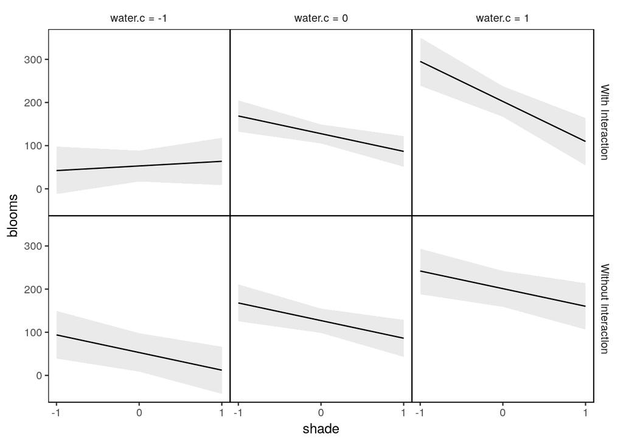

```r
ggplot(nd) +
  geom_ribbon(aes(x=shade, ymin=blooms_pi_l, ymax=blooms_pi_h), alpha = .1) +
  geom_line(aes(shade, blooms)) +
  scale_x_continuous(breaks = c(-1, 0, 1)) +
  theme(panel.border = element_rect(fill = NA),
        panel.spacing = unit(0, 'mm')) +
  facet_grid(bWS~water)
```

Not sure what was mean by data in the points as we created new data to predict blooms here.